# Imputatie COVID data

Hanne Oberman

2022-09-29

# 1 Packages and functions used

```r
# setup environment
library(haven)      # For importing SPSS data
library(readxl)     # For reading excel files
library(tidyverse)  # All things useful
library(mice)       # For incomplete data analysis
library(miceadds)   # Additions to mice
library(ggmice)     # Plotting device for mice
library(lme4)       # Linear mixed-effect modeling
library(plyr)       # Data wrangling
library(magrittr)   # Pipes in R

# Define function for `not in`
`%nin%` <- Negate(`%in%`)

# Function for the mode of a vector
modus <- function(x) {
  tally <- table(x, useNA = "no")
  if(dim(tally)==0) {
    mode <- NA
    } else {
      mode <- names(which.max(tally))
      }
  return(mode)
}

modus_per_column <- function(x) {
  apply(x, 2, modus)
}
```

# 2 Import the data

```r
dat_raw <- read_sav("data.zsav")
```

# 3 Data editing

## 3.1 Rename and clean labels and attributes

```r
# clean names
dat_rename <- janitor::clean_names(dat_raw)
# strip attributes
dat_rename[] <- lapply(dat_rename, as.vector)
vars <- names(dat_rename)
```

## 3.2 Make time dimension consistent and add polynomial for measurement occasion

The following step adds non-observed measurement occasions when participants do not have all measurement occasions observed.

```r
dat_meting <- expand.grid(id = unique(dat_rename$id), meting = 1:5)
dat_long <- full_join(dat_rename, dat_meting)
```

The following step recodes the measurement occasions into months and adds a quadratic term

```r
dat_long %<>%
  mutate(meting_mnd = recode_factor(meting,
                                    `1` = "0",
                                    `2` = "3",
                                    `3` = "7",
                                    `4` = "12",
                                    `5` = "17") %>%
           as.character() %>% as.numeric(),
         meting_squared = meting_mnd * meting_mnd)
```

## 3.3 Add the occupation of participants

First recode `isco` to `oesch`

```r
oesch <- read_excel("oesch.xlsx")
dat_oesch <- dat_long %>%
  mutate(isco08 = as.character(isco08))
dat_oesch$oesch <- mapvalues(dat_oesch$isco08,
                             from = oesch$ISCO,
                             to = oesch$OESCH)
```

Then clean the `oesch` codes and make the empty cells for occupation explicitly NA

```r
dat_clean <- dat_oesch %>%
  zap_labels() %>%
  select(-isco08, -weegfactor) %>%
  mutate(oesch = na_if(oesch, 99),
         oesch = na_if(oesch, 110),
         oesch = na_if(oesch, 310),
         oesch = na_if(oesch, 4111),
         oesch = na_if(oesch, 7536))
dat_clean$oesch[dat_clean$oesch == ""] <- NA
```

## 3.4 Combine health status question into a single variable

```r
dat_clean$q43 <- rowMeans(data.frame(dat_clean$q43_wave1, dat_clean$q43_wave2tot5), na.rm = TRUE)
dat_clean[sapply(dat_clean, is.nan)] <- NA
```

## 3.5 Select relevant variables

Create variable vectors for imputation models

```r
vars_outcome <- c("q60_1", "q49_1", "q49_2", "q49_3", "q49_4", "q49_5", "q49_6")
vars_fixed <- c("edu", "oesch", "geboortejaar", "q29", "q52", "q53", "q54", "sekse", "etn_herkomst")
vars_random <- c("meting_mnd", "meting_squared", "q43", "q48_1", "q48_9", "q48_10", "q48_11", "q48_12", "q47_1", "q47_2", "q47_3", "q33_1", "q33_2", "q33_3", "q33_4", "q33_5", "q33_6")
vars_covariates <- c("q34_1", "q34_2", "q34_3", "q34_4", "q34_5", "q38_1", "q38_2", "q38_3", "q38_4", "q31_1", "q31_2", "q31_3", "q31_4", "q31_5", "q31_6", "q31_7", "q59", "q60_2", "q60_3", "q60_4", "q60_8", "q60_10", "q60_12")
vars_analyse <- c("id", vars_outcome, vars_fixed, vars_random)
```

Filter the relevant variables

```r
# from the cleaned data, select the analysis variables and covariates
dat_clean <- dat_clean[c(vars_analyse, vars_covariates)]
vars <- names(dat_clean)
```

# 4 Imputation

## 4.1 Impute fixed variables

The following code takes the most frequent observation per participant across measurement occasions for variables that are assumed constant in the analysis model, and fills this value in for all measurement occasions

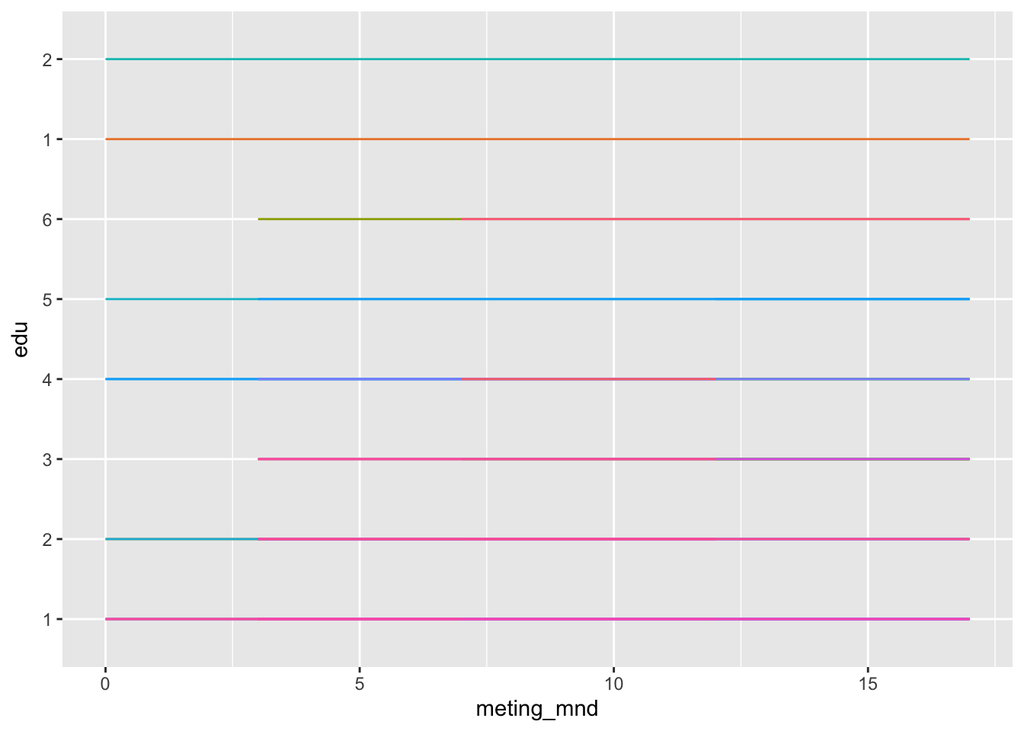

```r
# calculate mode for constant variables
modi <- split(dat_clean[, c("id", vars_fixed)], factor(dat_clean$id)) %>%
  map_dfr(~modus_per_column(.x)) %>%
  mutate(across(everything(), ~as.numeric(.x)),
         id = as.numeric(id))
# combine constants with the time-varying data
dat_imp <- dat_clean[, vars %nin% vars_fixed] %>%
  left_join(modi, by = "id")
# check if the constants are in fact constant across measurements
dat_imp[1:200,] %>%
  ggplot(aes(x = meting_mnd, y = edu, color = as.factor(id))) +
  geom_line() +
  theme(legend.position = "none")
```

## 4.2 Develop imputation models

First inspect missingness pattern and correlations

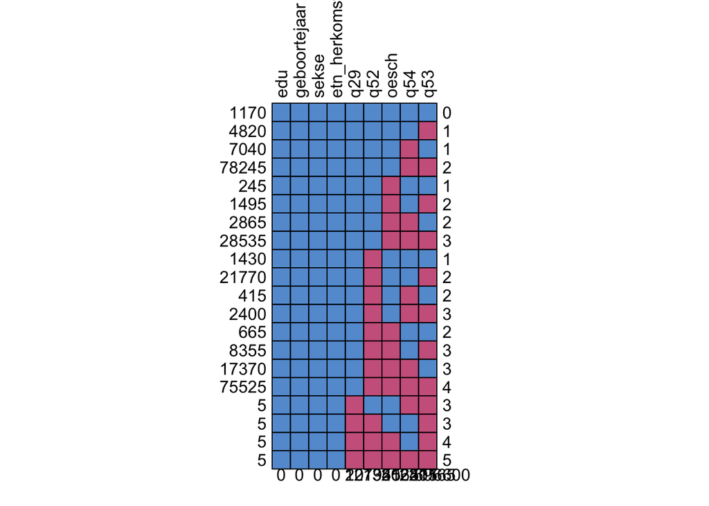

```
##       edu geboortejaar sekse etn_herkomst q29    q52  oesch    q54    q53
## 1170    1            1     1            1   1      1      1      1      1
## 4820    1            1     1            1   1      1      1      1      0
## 7040    1            1     1            1   1      1      1      0      1
## 78245   1            1     1            1   1      1      1      0      0
## 245     1            1     1            1   1      1      0      1      1
## 1495    1            1     1            1   1      1      0      1      0
## 2865    1            1     1            1   1      1      0      0      1
## 28535   1            1     1            1   1      1      0      0      0
## 1430    1            1     1            1   1      0      1      1      1
## 21770   1            1     1            1   1      0      1      1      0
## 415     1            1     1            1   1      0      1      0      1
## 2400    1            1     1            1   1      0      1      0      0
## 665     1            1     1            1   1      0      0      1      1
## 8355    1            1     1            1   1      0      0      1      0
```

[output cut: 29 more lines]

```r
md.pattern(dat_imp[vars_fixed], rotate.names = TRUE)
```

[figure not shown]

```
##         q60_1  q49_4  q49_5  q49_1  q49_6  q49_2  q49_3
## 93801       1      1      1      1      1      1      1       0
## 348         1      1      1      1      1      1      0       1
## 250         1      1      1      1      1      0      1       1
## 32          1      1      1      1      1      0      0       2
## 209         1      1      1      1      0      1      1       1
## 49          1      1      1      1      0      1      0       2
## 43          1      1      1      1      0      0      1       2
## 22          1      1      1      1      0      0      0       3
## 185         1      1      1      0      1      1      1       1
## 12          1      1      1      0      1      1      0       2
## 34          1      1      1      0      1      0      1       2
## 7           1      1      1      0      1      0      0       3
## 17          1      1      1      0      0      1      1       2
## 7           1      1      1      0      0      1      0       3
```

[output cut: 69 more lines]

```r
md.pattern(dat_imp[vars_outcome], rotate.names = TRUE)
```

```r
md.pattern(dat_imp[vars_random], rotate.names = TRUE, plot = FALSE)
```

```
##        meting_mnd meting_squared  q33_1    q43  q47_1  q33_3  q33_5  q33_2
## 58632           1              1      1      1      1      1      1      1
## 1434            1              1      1      1      1      1      1      1
## 897             1              1      1      1      1      1      1      1
## 103             1              1      1      1      1      1      1      1
## 803             1              1      1      1      1      1      1      1
## 121             1              1      1      1      1      1      1      1
## 226             1              1      1      1      1      1      1      1
## 41              1              1      1      1      1      1      1      1
## 526             1              1      1      1      1      1      1      1
## 331             1              1      1      1      1      1      1      1
## 72              1              1      1      1      1      1      1      1
## 40              1              1      1      1      1      1      1      1
## 41              1              1      1      1      1      1      1      1
## 29              1              1      1      1      1      1      1      1
```

[output cut: 1079 more lines]